# EDA Series

# Análise comparativa das séries American Idol, American Dad e Mr Robot

```r
data = read_csv(here("data/series_from_imdb.csv"), progress = FALSE,
                    col_types = cols(.default = col_double(),
                                     series_name = col_character(),
                                     episode = col_character(),
                                     url = col_character(),
                                     season = col_character()))
```

### Qual é a melhor avaliada?

Analisando os boxplots das avaliações dos episódios das séries Mr Robot, American Idol e American Dad, vemos que a série Mr Robot possui um range de avaliações bem mais agrupado acima da nota 8, mostrando que todos os episódios foram extremamente bem avaliados sem exceções. Ao compararmos as outras séries, percebemos um range de notas bem maior com notas inferiores às de Mr Robot, salvo raras exceções. Ou seja, olhando num contexto geral, Mr Robot foi um sucesso em todos os seus episódios, por outro lado American Idol aparentemente teve episódios distribuidas com mais de 50% deles aliados com notas muito baixas ou médias. American Dad, assim como Mr Robot, é uma série com episódios avaliados em notas bem próximas, porém quase 100% delas são abaixo das notas mais baixas de Mr Robot.

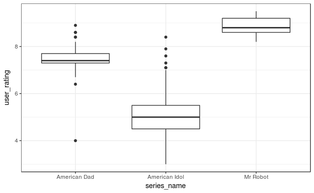

```r
data %>%
    filter(series_name %in% c("Mr Robot", "American Idol", "American Dad")) %>%
    ggplot(aes(x = series_name, y = user_rating)) +
            geom_boxplot()
```

### Mas será que é sempre assim?

Analisando o gráfico de dispersão abaixo, podemos analisar 3 coisas muito importantes, a primeira delas é que American Dad e American Idol tem muito mais episódios que Mr Robot, fazendo com que as notas fiquem mais variadas ao longo dos episódios (e apareçam muitos outliers), a segunda coisa que é importante notar é que Mr Robot tem muito mais avaliações que as outras duas séries, fazendo com que nas outras a nota individual tenha um peso muito maior.

Ainda com o gráfico abaixo, podemos perceber que a série American Idol tem um certo crescimento se observarmos que as notas acima de 5 no início da série são bem poucas bem como as abaixo de 6 nos ultimos episódios. Enquanto isso, em Mr Robot, vemos que a série possui altos e baixos, começa com uma avaliação incrível, cai um pouco, cresce novamente e é assim até o ultimo episódio, ao contrário de American Dad que se mantém praticamente na mesma faixa de notas durante todas as temporadas. Ainda analisando essa informação, podemos ver que de um episódio pro outro as notas são bem próximas na maioria dos casos, apesar de, por exemplo, notarmos uma diferença considerável quando comparamos o primeiro episódio de Mr Robot com o quarto, se compararmos o primeiro com o segundo vemos que não há tanta diferença assim, e isso se aplica às outras duas séries em boa parte dos episódios, apesar de algumas exceções notáveis.

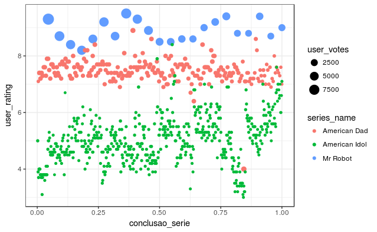

```r
data %>%
    filter(series_name %in% c("Mr Robot", "American Idol", "American Dad")) %>%
    group_by(series_name) %>%
    mutate(conclusao_serie = series_ep / max(series_ep)) %>%
    ggplot(aes(x = conclusao_serie, y = user_rating, color = series_name, size = user_votes)) +
      geom_point()
```